# Loading..

### **Useful Functions**

```python
#Create color dictionary
  color_dict = {
      'American' :'#0A3A8E',
      'United': '#05B0EC',
      'Delta':'#EC7105',
      'US Airways':'#CA8E03',
      'Southwest':'#BE03CA',
      'Virgin America':'#04D340',
      'negative':'#FF2D00',
      'neutral':'#959595',
      'positive':'#0156EA',
  }

  #Function to show %
  def autopct_format(values):
          def my_format(pct):
              total = sum(values)
              val = int(round(pct*total/100.0))
              return '{:.1f}%\n({v:d})'.format(pct, v=val)
          return my_format

  # function to create labeled barplots
  def labeled_barplot(data, feature, color_dict=None, perc=False, n=None, sort_order='desc', ax=None,
                      rotate_labels=None, title=None, xtick_fontsize=None, title_fontsize=None,
                      show_subtitle=True,
                      show_x_label_column=True, x_label=None,
                      show_y_label_column=True, y_label=None):
      """
      Barplot with percentage at the top
      data: dataframe
      feature: dataframe column
      color_dict: dictionary mapping labels to colors (optional)
      perc: whether to display percentages instead of count (default is False)
      n: displays the top n category levels (default is None, i.e., display all levels)
      sort_order: sorting order for the categories ('desc' for descending, 'asc' for ascending, 'alpha' for alphabetical)
      ax: subplot axes (optional)
      rotate_labels : rotate the x-axis label by certain degrees (optional)
      title : a string that is the title of the plot or subplot
      xtick_fontsize: font size for the x labels. If "None" then use default (optional)
      title_fontsize : font size for the title (if any). If "None" then use default (optional)
      show_subtitle:
      show_x_label: do not show x_label. If None, specify x_label. If x_label empty, then no x_label.
      x_label: use this text as the x label, to use x_label=None
      y_label: use this text as the y label
      """

      total = len(data[feature])  # length of the column
      count = data[feature].nunique()

      if ax is None:
          fig, ax = plt.subplots(figsize=(count + 2, 6))
      else:
          fig = ax.get_figure()

      if color_dict is None:
          palette = "flare"
          order = data[feature].value_counts().index[:n]
      else:
          if sort_order == 'desc':
              ordered_counts = data[feature].value_counts().sort_values(ascending=False)
          elif sort_order == 'asc':
              ordered_counts = data[feature].value_counts().sort_values(ascending=True)
          elif sort_order == 'alpha':
              ordered_counts = data[feature].value_counts().sort_index()
          else:
              raise ValueError("Invalid sort_order value. Use 'desc', 'asc', or 'alpha'.")

          order = list(ordered_counts.index)[:n]
          palette = [color_dict[label] for label in order]

      if rotate_labels is None:
          rotate_labels = 0
      else:
          rotate_labels = rotate_labels

      ax.set_xticklabels(order, rotation=rotate_labels, fontsize=xtick_fontsize)
      sns.countplot(data=data, x=feature, palette=palette, order=order, ax=ax)

      for p in ax.patches:
        if perc:
          label = "{:.1f}%".format(100 * p.get_height() / total)
        else:
          label = p.get_height()

        x = p.get_x() + p.get_width() / 2
        y = p.get_height()

        if not show_x_label_column:
          if x_label == "":
            ax.set(xlabel="")
          else:
            ax.set(xlabel=x_label)

        if not show_y_label_column:
          if y_label =="":
            ax.set(ylabel="")
          else:
            ax.set(ylabel=y_label)

        ax.annotate(
              label,
              (x, y),
              ha="center",
              va="center",
              size=12,
              xytext=(0, 5),
              textcoords="offset points",
          )

      if show_subtitle:
          ax.set_title(title, fontsize=title_fontsize)
      else:
          ax.set_title("", fontsize=title_fontsize)


      return ax


  def histogram_boxplot(data, feature, figsize=(15, 10), kde=False, bins=None):
      """
      Boxplot and histogram combined

      data: dataframe
      feature: dataframe column
      figsize: size of figure (default (15,10))
      kde: whether to show the density curve (default False)
      bins: number of bins for histogram (default None)
      """
      f2, (ax_box2, ax_hist2) = plt.subplots(
          nrows=2,  # Number of rows of the subplot grid= 2
          sharex=True,  # x-axis will be shared among all subplots
          gridspec_kw={"height_ratios": (0.25, 0.75)},
          figsize=figsize,
      )  # creating the 2 subplots
      sns.boxplot(
          data=data, x=feature, ax=ax_box2, showmeans=True, color="violet"
      )  # boxplot will be created and a triangle will indicate the mean value of the column
      sns.histplot(
          data=data, x=feature, kde=kde, ax=ax_hist2, bins=bins
      ) if bins else sns.histplot(
          data=data, x=feature, kde=kde, ax=ax_hist2
      )  # For histogram
      ax_hist2.axvline(
          data[feature].mean(), color="green", linestyle="--"
      )  # Add mean to the histogram
      ax_hist2.axvline(
          data[feature].median(), color="black", linestyle="-"
      )  # Add median to the histogram

  # function to plot stacked bar chart
  def stacked_barplot(data, predictor, target):
      """
      Print the category counts and plot a stacked bar chart

      data: dataframe
      predictor: independent variable
      target: target variable
      """
      count = data[predictor].nunique()
      sorter = data[target].value_counts().index[-1]
      tab1 = pd.crosstab(data[predictor], data[target], margins=True).sort_values(
          by=sorter, ascending=False
      )
      print(tab1)
      print("-" * 120)
      tab = pd.crosstab(data[predictor], data[target], normalize="index").sort_values(
          by=sorter, ascending=False
      )
      tab.plot(kind="bar", stacked=True, figsize=(count + 1, 5))
      plt.legend(
          loc="lower left",
          frameon=False,
      )
      plt.legend(loc="upper left", bbox_to_anchor=(1, 1))
      plt.show()

  # Function to print the classification report and get confusion matrix in a proper format
  def metrics_score(actual, predicted):

      print(classification_report(actual, predicted))

      cm = confusion_matrix(actual, predicted)

      plt.figure(figsize = (8, 5))

      sns.heatmap(cm, annot = True,  fmt = '.2f', xticklabels = ['negative', 'positive'], yticklabels = ['negative', 'positive'])

      plt.ylabel('Actual')

      plt.xlabel('Predicted')

      plt.show()

  def get_top40_words(model, all_features):

      # Addition of top 40 feature into top_feature after training the model
      top_features=''

      feat = model.feature_importances_

      features = np.argsort(feat)[::-1]

      for i in features[0:40]:
          top_features+=all_features[i]
          top_features+=','

      from wordcloud import WordCloud

      wordcloud = WordCloud(background_color = "white", colormap = 'viridis', width = 2000,
                                height = 1000).generate(top_features)

      # Display the generated image:
      plt.imshow(wordcloud, interpolation = 'bilinear')
      plt.figure(1, figsize = (10, 10), frameon='equal')
      plt.title('Top 40 features WordCloud', fontsize = 10)
      plt.axis("off")
      plt.show()
```

## **Loading and Interpreting the Data**

```python
#allow access to google drive
  from google.colab import drive
  drive.mount('/content/gdrive')
```

```python
#read csv file and load into a panda dataframe
  data = pd.read_csv('/content/gdrive/MyDrive/Projects/ML/Data/AirlineTweets.csv')
```

```python
#make a copy of dataframe
  dataw = data.copy()
```

**Shape of dataframe**

```python
#shape of data
  dataw.shape
```

```
(14640, 15)
```

**Dataframe info**

```python
dataw.info()
```

```
<class 'pandas.core.frame.DataFrame'>
  RangeIndex: 14640 entries, 0 to 14639
  Data columns (total 15 columns):
   #   Column                        Non-Null Count  Dtype
  ---  ------                        --------------  -----
   0   tweet_id                      14640 non-null  int64
   1   airline_sentiment             14640 non-null  object
   2   airline_sentiment_confidence  14640 non-null  float64
   3   negativereason                9178 non-null   object
   4   negativereason_confidence     10522 non-null  float64
   5   airline                       14640 non-null  object
   6   airline_sentiment_gold        40 non-null     object
   7   name                          14640 non-null  object
   8   negativereason_gold           32 non-null     object
   9   retweet_count                 14640 non-null  int64
   10  text                          14640 non-null  object
   11  tweet_coord                   1019 non-null   object
   12  tweet_created                 14640 non-null  object
   13  tweet_location                9907 non-null   object
   14  user_timezone                 9820 non-null   object
  dtypes: float64(2), int64(2), object(11)
  memory usage: 1.7+ MB
```

Notice there are null/missing values in the dataset.

**Visualize dataframe head**

```python
dataw.head()
```

|  | tweet_id | airline_sentiment | airline_sentiment_confidence | negativereason | negativereason_confidence | airline | airline_sentiment_gold | name | negativereason_gold | retweet_count | text | tweet_coord | tweet_created | tweet_location | user_timezone |
| --- | --- | --- | --- | --- | --- | --- | --- | --- | --- | --- | --- | --- | --- | --- | --- |
| 0 | 570306133677760513 | neutral | 1.0000 | NaN | NaN | Virgin America | NaN | cairdin | NaN | 0 | @VirginAmerica What @dhepburn said. | NaN | 2015-02-24 11:35:52 -0800 | NaN | Eastern Time (US & Canada) |
| 1 | 570301130888122368 | positive | 0.3486 | NaN | 0.0000 | Virgin America | NaN | jnardino | NaN | 0 | @VirginAmerica plus you've added commercials t... | NaN | 2015-02-24 11:15:59 -0800 | NaN | Pacific Time (US & Canada) |
| 2 | 570301083672813571 | neutral | 0.6837 | NaN | NaN | Virgin America | NaN | yvonnalynn | NaN | 0 | @VirginAmerica I didn't today... Must mean I n... | NaN | 2015-02-24 11:15:48 -0800 | Lets Play | Central Time (US & Canada) |
| 3 | 570301031407624196 | negative | 1.0000 | Bad Flight | 0.7033 | Virgin America | NaN | jnardino | NaN | 0 | @VirginAmerica it's really aggressive to blast... | NaN | 2015-02-24 11:15:36 -0800 | NaN | Pacific Time (US & Canada) |
| 4 | 570300817074462722 | negative | 1.0000 | Can't Tell | 1.0000 | Virgin America | NaN | jnardino | NaN | 0 | @VirginAmerica and it's a really big bad thing... | NaN | 2015-02-24 11:14:45 -0800 | NaN | Pacific Time (US & Canada) |

**Visualize dataframe tail**

```python
dataw.tail()
```

|  | tweet_id | airline_sentiment | airline_sentiment_confidence | negativereason | negativereason_confidence | airline | airline_sentiment_gold | name | negativereason_gold | retweet_count | text | tweet_coord | tweet_created | tweet_location | user_timezone |
| --- | --- | --- | --- | --- | --- | --- | --- | --- | --- | --- | --- | --- | --- | --- | --- |
| 14635 | 569587686496825344 | positive | 0.3487 | NaN | 0.0000 | American | NaN | KristenReenders | NaN | 0 | @AmericanAir thank you we got on a different f... | NaN | 2015-02-22 12:01:01 -0800 | NaN | NaN |
| 14636 | 569587371693355008 | negative | 1.0000 | Customer Service Issue | 1.0000 | American | NaN | itsropes | NaN | 0 | @AmericanAir leaving over 20 minutes Late Flig... | NaN | 2015-02-22 11:59:46 -0800 | Texas | NaN |
| 14637 | 569587242672398336 | neutral | 1.0000 | NaN | NaN | American | NaN | sanyabun | NaN | 0 | @AmericanAir Please bring American Airlines to... | NaN | 2015-02-22 11:59:15 -0800 | Nigeria,lagos | NaN |
| 14638 | 569587188687634433 | negative | 1.0000 | Customer Service Issue | 0.6659 | American | NaN | SraJackson | NaN | 0 | @AmericanAir you have my money, you change my ... | NaN | 2015-02-22 11:59:02 -0800 | New Jersey | Eastern Time (US & Canada) |
| 14639 | 569587140490866689 | neutral | 0.6771 | NaN | 0.0000 | American | NaN | daviddtwu | NaN | 0 | @AmericanAir we have 8 ppl so we need 2 know h... | NaN | 2015-02-22 11:58:51 -0800 | dallas, TX | NaN |

**Features Description**

```python
#create list to hold features
  col_names = []
  for col in dataw.columns:
    col_names.append(col)

  print(col_names)
```

```
['tweet_id', 'airline_sentiment', 'airline_sentiment_confidence', 'negativereason', 'negativereason_confidence', 'airline', 'airline_sentiment_gold', 'name', 'negativereason_gold', 'retweet_count', 'text', 'tweet_coord', 'tweet_created', 'tweet_location', 'user_timezone']
```

```python
#create list to hold datatypes
  col_types = []
  for x in dataw.dtypes:
    col_types.append(x)

  print(col_types)
```

```
[dtype('int64'), dtype('O'), dtype('float64'), dtype('O'), dtype('float64'), dtype('O'), dtype('O'), dtype('O'), dtype('O'), dtype('int64'), dtype('O'), dtype('O'), dtype('O'), dtype('O'), dtype('O')]
```

Features description gathered from dataframe review.

- tweet_id: unique id number of the tweet.
- airline_sentiment: positive, negative or neutral sentiment towards the airline.
- airline_sentiment_confidence: how confident the airline sentiment is.
- negativereason: Very short reference to why the sentiment was negative.
- airline: Name of the airline
- airline_sentiment_gold: I am not sure what this is.
- name: Name of the tweeter
- negativereason_gold: I am not sure what this is.
- retweet_count: How many times the tweet was retweeted.
- text: content of the tweet.
- tweet_coord: geographical coordinates where the tweet originated in latitude and longitude.
- tweet_created: data and time when the tweet was created.
- tweet_location: the location where the tweeter originated the tweet.
- user_timezone: timezone where the user lives.

```python
desc = ['unique id number of the tweet.','positive, negative or neutral sentiment towards the airline.','How confident the airline sentiment is.',
               'Very short reference to why the sentiment was negative.','Name of the airline','I am not sure what this is.','Name of the tweeter.',
               'I am not sure what this is.','How many times the tweet was retweeted.;','Content of the tweet.',
               'Geographical coordinates where the tweet originated in latitude and longitude.','Data and time when the tweet was created.',
               'The location where the tweeter originated the tweet.','Timezone where the tweet originated.','Timezone where the user lives.']
```

**Data fields Interpretation**

```python
#extend columns width so all the text can be visualized
  pd.set_option('display.max_colwidth',None)
```

```python
#assemble a dataframe to summarize features description
  feature_data = {'Feature':col_names,
                  'data_type': col_types,
                  'description': desc }
  features_df = pd.DataFrame(feature_data)
  features_df
```

[output not shown]

**Unique entries**

```python
dataw.nunique()
```

```
tweet_id                        14485
  airline_sentiment                   3
  airline_sentiment_confidence     1023
  negativereason                     10
  negativereason_confidence        1410
  airline                             6
  airline_sentiment_gold              3
  name                             7701
  negativereason_gold                13
  retweet_count                      18
  text                            14427
  tweet_coord                       832
  tweet_created                   14247
  tweet_location                   3081
  user_timezone                      85
  dtype: int64
```

**Check duplicated entries**

```python
#Duplicated data
  dups = dataw.duplicated().sum()
  print("There are ",dups, " duplicated entries in the dataset.")
```

```
There are  36  duplicated entries in the dataset.
```

There are 36 duplicated entries See below:

```python
#visualize samples of duplicated entries
  text_dups = dataw["text"]
  sorteddups = dataw[text_dups.isin(text_dups[text_dups.duplicated()])].sort_values("text")
  pd.options.display.max_rows =int(dups)
  sorteddups.head(dups)
```

|  | tweet_id | airline_sentiment | airline_sentiment_confidence | negativereason | negativereason_confidence | airline | airline_sentiment_gold | name | negativereason_gold | retweet_count | text | tweet_coord | tweet_created | tweet_location | user_timezone |
| --- | --- | --- | --- | --- | --- | --- | --- | --- | --- | --- | --- | --- | --- | --- | --- |
| 12067 | 570301488192458752 | negative | 1.0000 | Customer Service Issue | 1.0000 | American | NaN | skgiffard | NaN | 0 | .@AmericanAir can you connect me to a person without having to wait 2+ hours on hold? I still haven't been able to resolve the problem. | NaN | 2015-02-24 11:17:25 -0800 | Boston, MA | Eastern Time (US & Canada) |
| 11906 | 570301488192458752 | negative | 0.6703 | Customer Service Issue | 0.6703 | American | NaN | skgiffard | NaN | 0 | .@AmericanAir can you connect me to a person without having to wait 2+ hours on hold? I still haven't been able to resolve the problem. | NaN | 2015-02-24 11:17:25 -0800 | Boston, MA | Eastern Time (US & Canada) |
| 11902 | 570303383782989824 | neutral | 1.0000 | NaN | NaN | American | NaN | trentgillaspie | NaN | 0 | .@AmericanAir just disappointed with the Flight Booking Problems process and add’l fees to sit together on a more crowded flight. Not impressed so far :-/. | NaN | 2015-02-24 11:24:57 -0800 | Austin, but often Denver | Mountain Time (US & Canada) |
| 12063 | 570303383782989824 | neutral | 1.0000 | NaN | NaN | American | NaN | trentgillaspie | NaN | 0 | .@AmericanAir just disappointed with the Flight Booking Problems process and add’l fees to sit together on a more crowded flight. Not impressed so far :-/. | NaN | 2015-02-24 11:24:57 -0800 | Austin, but often Denver | Mountain Time (US & Canada) |
| 11946 | 570288282413633536 | negative | 1.0000 | Lost Luggage | 0.6593 | American | NaN | jacquelinewins6 | NaN | 0 | @AmericanAir\n Your response could have made all the difference. It could have made the situation better. NO TRUST...GET LOST like my bag. | NaN | 2015-02-24 10:24:56 -0800 | NaN | NaN |
| 12107 | 570288282413633536 | negative | 1.0000 | Lost Luggage | 1.0000 | American | NaN | jacquelinewins6 | NaN | 0 | @AmericanAir\n Your response could have made all the difference. It could have made the situation better. NO TRUST...GET LOST like my bag. | NaN | 2015-02-24 10:24:56 -0800 | NaN | NaN |
| 12128 | 570281010606120960 | negative | 1.0000 | Can't Tell | 0.6590 | American | NaN | jacquelinewins6 | NaN | 0 | @AmericanAir \nIt's not what happens to us that matters...It's our response that matters. Way to drop the ball AA. | NaN | 2015-02-24 09:56:02 -0800 | NaN | NaN |
| 11967 | 570281010606120960 | negative | 1.0000 | Customer Service Issue | 0.6523 | American | NaN | jacquelinewins6 | NaN | 0 | @AmericanAir \nIt's not what happens to us that matters...It's our response that matters. Way to drop the ball AA. | NaN | 2015-02-24 09:56:02 -0800 | NaN | NaN |
| 13995 | 569680231012773888 | negative | 1.0000 | Customer Service Issue | 1.0000 | American | NaN | LBernieMeyer | NaN | 0 | @AmericanAir 800 number will not even let you wait for next customer rep. Very frustrating. Can't talk to humans. | NaN | 2015-02-22 18:08:45 -0800 | NaN | NaN |
| 12029 | 569680231012773888 | negative | 1.0000 | Customer Service Issue | 0.9620 | American | negative | LBernieMeyer | Customer Service Issue | 0 | @AmericanAir 800 number will not even let you wait for next customer rep. Very frustrating. Can't talk to humans. | NaN | 2015-02-22 18:08:45 -0800 | NaN | NaN |
| 11973 | 570279653337927680 | positive | 1.0000 | NaN | NaN | American | NaN | sundialtours | NaN | 0 | @AmericanAir "Airport snow removal method #22..."\nKeep up the good work folks, this is where Cessna's become 747's! http://t.co/oUmC1LrXDN | NaN | 2015-02-24 09:50:39 -0800 | Astoria, OR | Tijuana |
| 12134 | 570279653337927680 | positive | 1.0000 | NaN | NaN | American | NaN | sundialtours | NaN | 0 | @AmericanAir "Airport snow removal method #22..."\nKeep up the good work folks, this is where Cessna's become 747's! http://t.co/oUmC1LrXDN | NaN | 2015-02-24 09:50:39 -0800 | Astoria, OR | Tijuana |
| 12105 | 570289085354541058 | negative | 1.0000 | Lost Luggage | 1.0000 | American | NaN | brownsrock | NaN | 0 | @AmericanAir - Please find my bag!! In Singapore for three days already without my bag. Last known destination LAX Tag: 580815 Please help. | NaN | 2015-02-24 10:28:08 -0800 | Bangkok, Thailand | Bangkok |
| 11944 | 570289085354541058 | negative | 1.0000 | Lost Luggage | 1.0000 | American | NaN | brownsrock | NaN | 0 | @AmericanAir - Please find my bag!! In Singapore for three days already without my bag. Last known destination LAX Tag: 580815 Please help. | NaN | 2015-02-24 10:28:08 -0800 | Bangkok, Thailand | Bangkok |
| 11962 | 570282469791911936 | neutral | 1.0000 | NaN | NaN | American | NaN | mrespinosa1971 | NaN | 0 | @AmericanAir - keeping AA up in the Air! My crew chief cousin Alex Espinosa in DFW! http://t.co/0HXLNvZknP | NaN | 2015-02-24 10:01:50 -0800 | Great State of Texas | Central Time (US & Canada) |
| 12123 | 570282469791911936 | positive | 0.6710 | NaN | NaN | American | NaN | mrespinosa1971 | NaN | 0 | @AmericanAir - keeping AA up in the Air! My crew chief cousin Alex Espinosa in DFW! http://t.co/0HXLNvZknP | NaN | 2015-02-24 10:01:50 -0800 | Great State of Texas | Central Time (US & Canada) |
| 12053 | 570306260010176512 | negative | 1.0000 | Customer Service Issue | 0.6728 | American | NaN | HollyKinnamon | NaN | 0 | @AmericanAir 1hr 46 min. Cost of flight change $788. Was $188 2hrs ago b/f drop call. Cancelled Flighted flight. Asked 4 refund. | NaN | 2015-02-24 11:36:22 -0800 | Washington, DC | Quito |
| 11892 | 570306260010176512 | negative | 1.0000 | Flight Booking Problems | 0.3488 | American | NaN | HollyKinnamon | NaN | 0 | @AmericanAir 1hr 46 min. Cost of flight change $788. Was $188 2hrs ago b/f drop call. Cancelled Flighted flight. Asked 4 refund. | NaN | 2015-02-24 11:36:22 -0800 | Washington, DC | Quito |
| 12179 | 570268420140244992 | negative | 1.0000 | Cancelled Flight | 1.0000 | American | NaN | farfalla818 | NaN | 0 | @AmericanAir 4th flight rebooked to is NOT Cancelled Flighted! Woo-hoo. Going to make it to @LaGuardiaAir | NaN | 2015-02-24 09:06:01 -0800 | Plano, Texas | NaN |
| 12018 | 570268420140244992 | negative | 0.6712 | Customer Service Issue | 0.6712 | American | NaN | farfalla818 | NaN | 0 | @AmericanAir 4th flight rebooked to is NOT Cancelled Flighted! Woo-hoo. Going to make it to @LaGuardiaAir | NaN | 2015-02-24 09:06:01 -0800 | Plano, Texas | NaN |
| 12050 | 570306662575300611 | neutral | 1.0000 | NaN | NaN | American | NaN | gjeaviation | NaN | 0 | @AmericanAir 767 seconds from touchdown at Madrid airport in April 2013 #AvGeek http://t.co/1yWXRfn0Gr | NaN | 2015-02-24 11:37:58 -0800 | Worcester, UK | London |
| 11889 | 570306662575300611 | neutral | 0.6742 | NaN | NaN | American | NaN | gjeaviation | NaN | 0 | @AmericanAir 767 seconds from touchdown at Madrid airport in April 2013 #AvGeek http://t.co/1yWXRfn0Gr | NaN | 2015-02-24 11:37:58 -0800 | Worcester, UK | London |
| 12130 | 570280641771790336 | positive | 1.0000 | NaN | NaN | American | NaN | LordLasenby | NaN | 0 | @AmericanAir @Clarkey_19 we done it with 1 truck... No biggie 😄 | NaN | 2015-02-24 09:54:34 -0800 | NaN | London |
| 11969 | 570280641771790336 | neutral | 1.0000 | NaN | NaN | American | NaN | LordLasenby | NaN | 0 | @AmericanAir @Clarkey_19 we done it with 1 truck... No biggie 😄 | NaN | 2015-02-24 09:54:34 -0800 | NaN | London |
| 12100 | 570290552169734144 | neutral | 0.6808 | NaN | NaN | American | NaN | saianel | NaN | 0 | @AmericanAir @RobertDwyer AA doesnt charge any fees to change award tickets as long as the origin, destination &amp; award type remains the same | NaN | 2015-02-24 10:33:57 -0800 | Texas | Mountain Time (US & Canada) |
| 11939 | 570290552169734144 | positive | 0.6752 | NaN | 0.0000 | American | NaN | saianel | NaN | 0 | @AmericanAir @RobertDwyer AA doesnt charge any fees to change award tickets as long as the origin, destination &amp; award type remains the same | NaN | 2015-02-24 10:33:57 -0800 | Texas | Mountain Time (US & Canada) |
| 12028 | 569699455919726593 | negative | 1.0000 | Customer Service Issue | 1.0000 | American | negative | JanssenMA | Customer Service Issue | 0 | @AmericanAir @SouljaCoy what is AA going to do to fix their utterly embarrassing customer service? You won't even answer the dang phone! | NaN | 2015-02-22 19:25:09 -0800 | NaN | NaN |
| 13864 | 569699455919726593 | negative | 1.0000 | Customer Service Issue | 1.0000 | American | NaN | JanssenMA | NaN | 0 | @AmericanAir @SouljaCoy what is AA going to do to fix their utterly embarrassing customer service? You won't even answer the dang phone! | NaN | 2015-02-22 19:25:09 -0800 | NaN | NaN |
| 12005 | 570271479616573440 | positive | 0.6630 | NaN | NaN | American | NaN | PappasitosTXMEX | NaN | 0 | @AmericanAir @beantownmatty Sounds like a date! | NaN | 2015-02-24 09:18:10 -0800 | NaN | Central Time (US & Canada) |
| 12166 | 570271479616573440 | positive | 1.0000 | NaN | NaN | American | NaN | PappasitosTXMEX | NaN | 0 | @AmericanAir @beantownmatty Sounds like a date! | NaN | 2015-02-24 09:18:10 -0800 | NaN | Central Time (US & Canada) |
| 12024 | 570264948548313088 | positive | 1.0000 | NaN | NaN | American | positive | Runts54 | NaN | 0 | @AmericanAir @dfwairport you 2 together are the best part of flying! | NaN | 2015-02-24 08:52:13 -0800 | Euless, Texas | NaN |
| 12196 | 570264948548313088 | positive | 1.0000 | NaN | NaN | American | NaN | Runts54 | NaN | 0 | @AmericanAir @dfwairport you 2 together are the best part of flying! | NaN | 2015-02-24 08:52:13 -0800 | Euless, Texas | NaN |
| 12013 | 570269774594224128 | negative | 0.6932 | Cancelled Flight | 0.6932 | American | NaN | rqualls | NaN | 0 | @AmericanAir @lpalumbo what weather sun is out | NaN | 2015-02-24 09:11:24 -0800 | NaN | NaN |
| 12174 | 570269774594224128 | negative | 0.7148 | Can't Tell | 0.3889 | American | NaN | rqualls | NaN | 0 | @AmericanAir @lpalumbo what weather sun is out | NaN | 2015-02-24 09:11:24 -0800 | NaN | NaN |
| 12097 | 570292403309035520 | neutral | 1.0000 | NaN | NaN | American | NaN | pbpinftworth | NaN | 0 | @AmericanAir @pbpinftworth iPhone 6 64GB (not 6 plus) | [32.82813261, -97.25115941] | 2015-02-24 10:41:19 -0800 | DFW, TX | Central Time (US & Canada) |
| 11936 | 570292403309035520 | neutral | 1.0000 | NaN | NaN | American | NaN | pbpinftworth | NaN | 0 | @AmericanAir @pbpinftworth iPhone 6 64GB (not 6 plus) | [32.82813261, -97.25115941] | 2015-02-24 10:41:19 -0800 | DFW, TX | Central Time (US & Canada) |

**Check Missing/Null values**

```python
#Check missing values
  dataw.isna().sum()
```

```
tweet_id                            0
  airline_sentiment                   0
  airline_sentiment_confidence        0
  negativereason                   5462
  negativereason_confidence        4118
  airline                             0
  airline_sentiment_gold          14600
  name                                0
  negativereason_gold             14608
  retweet_count                       0
  text                                0
  tweet_coord                     13621
  tweet_created                       0
  tweet_location                   4733
  user_timezone                    4820
  dtype: int64
```

Notice that there are features that are mostly null or empty.

These are:

- airline_sentiment_gold (14600 ~ 100% empty/null)
- negativereason_gold (14608 ~ 100% empty/null)
- tweet_coord (13621 ~ 93% empty/null)

These features have also many empty/null entries.

- negativereason (5462 ~ 37% empty/null)
- negativereason_confidence (4118 ~ 28% empty/null)
- tweet_location (4733 ~ 32% empty/null)
- user_timezone (4820 ~ 32% empty/null)

We anticipate that airline_sentiment_gold, negativereason_gold, and tweet_cord will be dropped. Simply because the first two are entirely null and third one, has more than 90% null values.

## **Exploratory data analysis**

### **Overall Tweets Distribution by Airline**

- Plot the distribution of all tweets among each airline & plot the distribution of sentiment across all the tweets.

```python
airlines = {"Airline": dataw['airline'].unique()}
  airlines_df = pd.DataFrame(airlines).sort_values(by='Airline', ascending=True)
  no_airlines = dataw['airline'].unique().sum()
  print("There are ",no_airlines, " airlines in the dataset.")
  airlines_df.style.hide_index()
```

```
There are  Virgin AmericaUnitedSouthwestDeltaUS AirwaysAmerican  airlines in the dataset.
```

| Airline |
| --- |
| American |
| Delta |
| Southwest |
| US Airways |
| United |
| Virgin America |

There are 6 different airlines in the dataset.

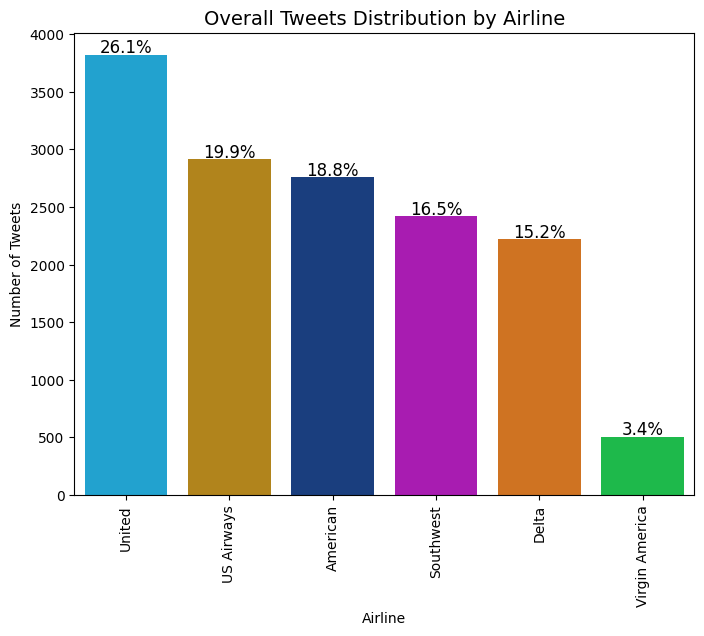

```python
labeled_barplot(dataw,"airline", color_dict, perc=True, sort_order='desc', rotate_labels=90, title="Overall Tweets Distribution by Airline",
                  xtick_fontsize=10, title_fontsize=14, show_x_label_column=False,x_label="Airline",
                  show_y_label_column=False, y_label="Number of Tweets")
  plt.show()
```

```python
# Count the number of occurrences of each airline
  airline_counts = dataw['airline'].value_counts().reset_index()

  # Rename the columns
  airline_counts.columns = ['airline', 'count']

  # Calculate the percentage
  airline_counts['percentage'] = (airline_counts['count'] / len(dataw)) * 100

  # Format the percentage column to display two decimal places
  airline_counts['percentage'] = airline_counts['percentage'].map('{:.2f}%'.format)

  # Sort the dataframe by count in descending order
  airline_counts = airline_counts.sort_values('count', ascending=False)

  # Reset the index
  airline_counts = airline_counts.reset_index(drop=True)

  # Remove the column name 'airline'
  airline_counts.columns = ['', 'count', 'percentage']

  # Display the resulting dataframe without the column name 'airline'
  print(airline_counts.to_string(index=False))
```

```
                count percentage
          United   3822     26.11%
      US Airways   2913     19.90%
        American   2759     18.85%
       Southwest   2420     16.53%
           Delta   2222     15.18%
  Virgin America    504      3.44%
```

United has 26% of all tweets and Virgin America only 3.4%. American 19% and Delta 15%. Notice that American, Delta, and United were the three largest US airlines. Lets keep in mind that the dataset may only include some regions of the US, to be found out later.

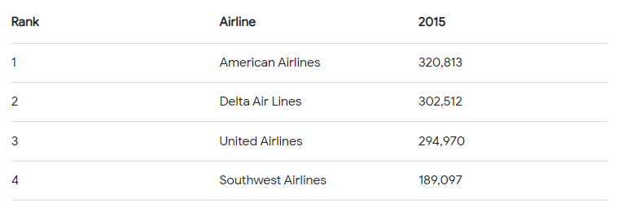

**Overall Airline Sentiment Class Distributon for all airlines**

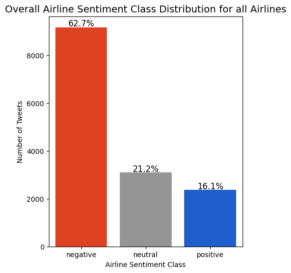

```python
labeled_barplot(dataw,"airline_sentiment", color_dict, perc=True,sort_order="alpha", title="Overall Airline Sentiment Class Distribution for all Airlines",
                  xtick_fontsize=10, title_fontsize=14, show_x_label_column=False,
                  x_label="Airline Sentiment Class", show_y_label_column=False, y_label="Number of Tweets")
  plt.show()
```

```python
# Count the number of occurrences of each sentiment class
  sent_counts = dataw['airline_sentiment'].value_counts().reset_index()

  # Rename the columns
  sent_counts.columns = ['airline_sentiment', 'count']

  # Calculate the percentage
  sent_counts['percentage'] = (sent_counts['count'] / len(dataw)) * 100

  # Format the percentage column to display two decimal places
  sent_counts['percentage'] = sent_counts['percentage'].map('{:.2f}%'.format)

  # Sort the dataframe by count in descending order
  sent_counts = sent_counts.sort_values('count', ascending=False)

  # Reset the index
  sent_counts = sent_counts.reset_index(drop=True)

  # Remove the column name 'airline'
  sent_counts.columns = ['sentiment', 'count', 'percentage']

  # Display the resulting dataframe without the column name 'sentiment'
  print(sent_counts.to_string(index=False))
```

```
sentiment  count percentage
   negative   9178     62.69%
    neutral   3099     21.17%
   positive   2363     16.14%
```

The dataset contains an overwhelming 63% negative airline sentiment class, a 21% neutral sentiment class, and a 16% positive sentiment class. While the labeled data is imbalanced, this is what we expected. Most customers are quick to express negative feelings about a service, and significantly less customers will express positive feelings. Therefore, although imbalanced, the labeled dataset is good.

**Airline Sentiment Class Distribution for each airline**

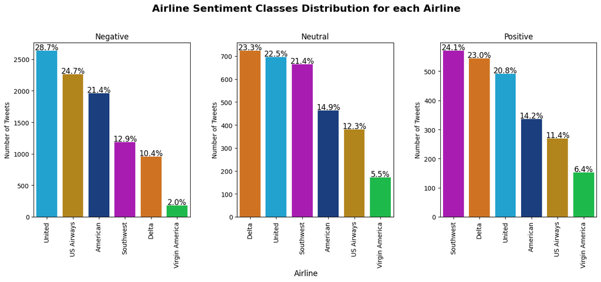

```python
sentiments = ['negative', 'neutral', 'positive']
  titles = ['Negative', 'Neutral', 'Positive']
  subtitle = 'Airline Sentiment Classes Distribution for each Airline'
  bottomtitle = 'Airline'

  fig, axes = plt.subplots(1, 3, figsize=(16, 5))
  fig.subplots_adjust(hspace=0.5, wspace=0.3)

  for idx, sentiment in enumerate(sentiments):
      airline_data = dataw[dataw['airline_sentiment'] == sentiment]
      ax = axes[idx]

      labeled_barplot(airline_data, "airline", color_dict, perc=True, sort_order='desc', rotate_labels=90, ax=ax, title=titles[idx], xtick_fontsize=10, title_fontsize=12,
                      show_x_label_column=False,
                      show_y_label_column=False, y_label="Number of Tweets")

     # ax.set_xlabel('')
     # ax.set_ylabel("Count", fontsize=10)

  fig.suptitle(subtitle, fontsize=16, fontweight='bold', ha='center', y=1.05)
  fig.text(0.5, -0.15, bottomtitle, fontsize=12, ha='center')
  plt.show()
```

To understand the above plots, keep in mind that the percentages are the distribution within their class.

Lets take a look at the Negative sentiment plot first. United has 29% of all negative sentiment tweets, US Airways has 25%, American has 21%, Southwest 13%, and Delta 10%. Remember that United has 26% of all tweets, US Airways 20%, American 19%, Southwest 17%, and Delta 15%.

In the Neutral sentiment plot we noticed that Delta has 23%, United 23%, Southwest 21%, American 15%, USAirways 12%.

In the Positive sentiment plot, Southwest leads with 24%, Delta has 23%, United 21%, American 14%, USAirways 11%.

To actually get a better glimpse of how each airline fared, we should consider the sentiment class distribution for each airline as percentages within their own group, as we will do next.

**Airline Sentiment Class Distribution for each Airline**

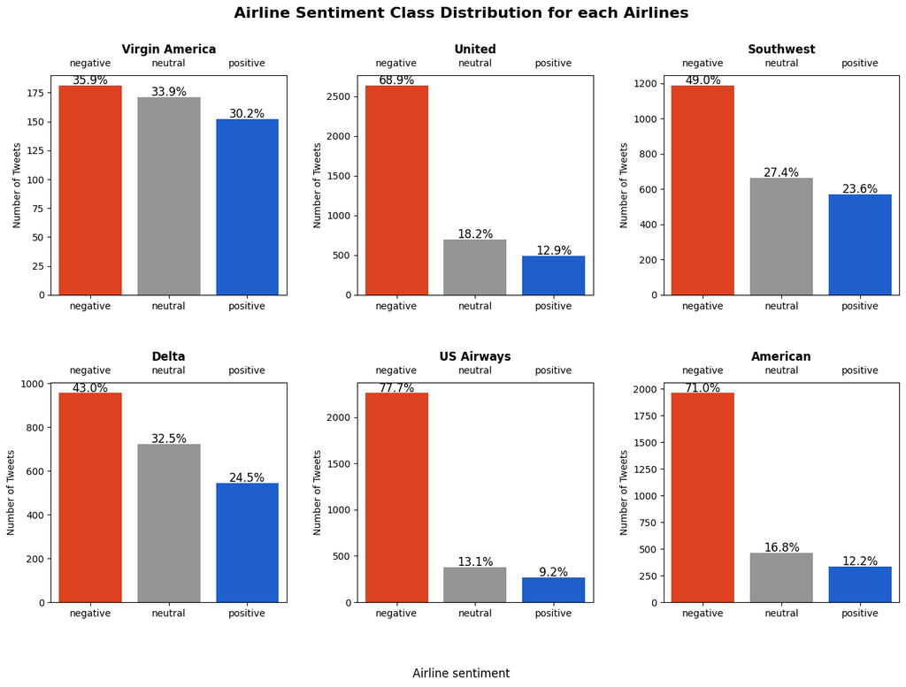

```python
# Define the data and subplots for airline Sentiment Distribution
  fig, axes = plt.subplots(2, 3, figsize=(16, 10))
  fig.subplots_adjust(hspace=0.4, wspace=0.3)

  subtitle = 'Airline Sentiment Distribution'
  bottomtitle = 'Airline sentiment'

  airlines = dataw['airline'].unique()

  for idx, airline in enumerate(airlines):
      airline_data = dataw[dataw['airline'] == airline]
      row = idx // 3
      col = idx % 3
      ax = axes[row, col]

      labeled_barplot(airline_data, "airline_sentiment", color_dict, perc=True, sort_order="alpha", ax=ax, title=airline,
                      xtick_fontsize=10, title_fontsize=12,
                      show_x_label_column=False, x_label = "",
                      show_y_label_column=False, y_label ="Number of Tweets")

      ax.set_xlabel('')


      ax.set_title(airline, fontsize=12, fontweight='bold')
      ax.set_xticklabels(ax.get_xticklabels(), visible=True)

  plt.suptitle("Airline Sentiment Class Distribution for each Airlines", fontsize=16, fontweight='bold')
  fig.text(0.5, 0.0, bottomtitle, fontsize=12, ha='center')
  plt.show()
```

For the above plots, notice that each bar for every sentiment class represents the percentage of each class for the total number of tweets for each airline.

From the above plots we can see better the level of negativity or positivity of the tweets.

2.United, American, US Airways all overwhelmingly have very large negative class sentiment percentages compared to neutral and positive classes. US Airways is the most negative. Roughly, all these airlines show a 70%-20%-10% for negative, neutral, ad positive distribution.

3.Delta and Southwest show more balance between classes that the previous three. Roughly, they show 45%-30%-25%.

Of the six airlines, Virgin America seems to outperform all. However, keep in mind that Virgin America is a much smaller airline compared to the others. Larger operations have more problems. Other factors include whether the airlines flew to the same locations or number of flights within the same location. For example, what if a region experienced severe weather or an airport was closed due to a technical difficulty?

Below we will plot the sentiment class distribution for every airlines as stacked plots.

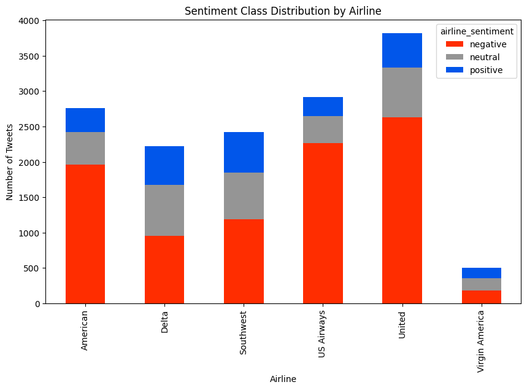

```python
grouped_airline_data = dataw.groupby(['airline', 'airline_sentiment']).size().unstack()

  # Create a stacked bar plot
  fig, ax = plt.subplots(figsize=(10, 6))
  grouped_airline_data.plot(kind='bar', stacked=True, ax=ax, color = color_dict)

  # Set the labels and title
  ax.set_xlabel('Airline')
  ax.set_ylabel('Number of Tweets')
  ax.set_title('Sentiment Class Distribution by Airline')

  # Show the plot
  plt.show()
```

It is difficult to make conclusions from the above plot. However, I could guess that US Airways is probably the airline that has the largest negative proportion to neutral and positive, followed by American, and United. From the previous plot, we noticed that US Airways had 77.7% negative, 13.1% neutral, and 9.2% positive, American 71% negative, 16.8% neutral, and 12.2% positive, United 68.9% negative, 18.2% neutral, and 12.9% positive. So it seems that US airways is the airline that had more negative sentiment tweets within its customers, followed by American, and United.

**Word Clouds**

**Word Cloud Negative Sentiment**

```python
#create a dataframe of only negative sentiments
  negative_reasons = dataw[dataw['airline_sentiment']=='negative']

  #join negative reviews using a separator
  words = ' '.join(negative_reasons['text'])

  #remove the \n characters from words
  cleaned_words = ' '.join([word for word in words.split()])
```

```python
# creating the wordcloud using the WordCloud() method
  wordcloud = WordCloud(stopwords = STOPWORDS,
                        colormap = 'RdBu',
                        background_color = 'white',
                        width = 3000,
                        height = 2500
                       ).generate(cleaned_words) # The generate() function takes one argument of the text we created, helps to generate the wordclouds
```

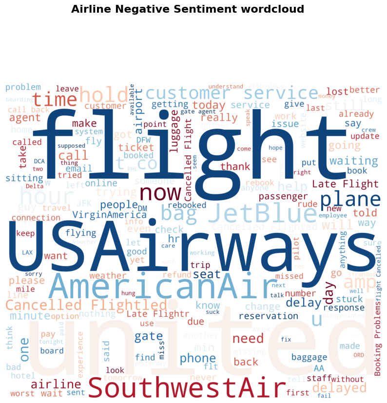

```python
plt.figure(1, figsize = (10, 10))
  plt.suptitle("Airline Negative Sentiment wordcloud", fontsize=16, fontweight='bold')
  # Using the .imshow() method of matplotlib.pyplot to display the Word Cloud as an image.
  plt.imshow(wordcloud)
  plt.axis('off')
  plt.show()
```

Notice most frequent words: "flight", "AmericanAir", "USAirways","SouthwestAir", "JetBlue", "now", "hold", "plane", "customer service", "bag", "hour", "time", "u", "delayed".

**Word Cloud Positive Sentiment**

```python
#create a dataframe of only positive sentiments
  positive_reasons = dataw[dataw['airline_sentiment']=='positive']

  ##join negative reviews using a separator
  words = ' '.join(positive_reasons['text'])

  #remove the \n characters from words
  cleaned_words = ' '.join([word for word in words.split()])
```

```python
# creating the wordcloud using the WordCloud() method
  wordcloud = WordCloud(stopwords = STOPWORDS,
                        colormap = 'RdBu',
                        background_color = 'white',
                        width = 3000,
                        height = 2500
                       ).generate(cleaned_words) # The generate() function takes one argument of the text we created, helps to generate the wordclouds
```

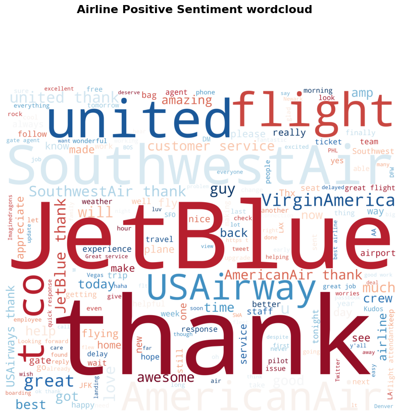

```python
plt.figure(1, figsize = (10, 10))
  plt.suptitle("Airline Positive Sentiment wordcloud", fontsize=16, fontweight='bold')
  # Using the .imshow() method of matplotlib.pyplot to display the Word Cloud as an image.
  plt.imshow(wordcloud)
  plt.axis('off')
  plt.show()
```

Notice some of the most common words: "thank", "JetBlue", "united", " AmericanAir", "VirginAmerica", "JetBlue thank", "awesome", "SouthwestAir thank", "much", "guy", "AmericanAir thank", "USAirway", "customer service", "help".

**Word Cloud Neutral Sentiment**

```python
#create a dataframe of only neutral sentiments
  positive_reasons = dataw[dataw['airline_sentiment']=='neutral']

  ##join negative reviews using a separator
  words = ' '.join(positive_reasons['text'])

  #remove the \n characters from words
  cleaned_words = ' '.join([word for word in words.split()])
```

```python
# creating the wordcloud using the WordCloud() method
  wordcloud = WordCloud(stopwords = STOPWORDS,
                        colormap = 'RdBu',
                        background_color = 'white',
                        width = 3000,
                        height = 2500
                       ).generate(cleaned_words) # The generate() function takes one argument of the text we created, helps to generate the wordclouds
```

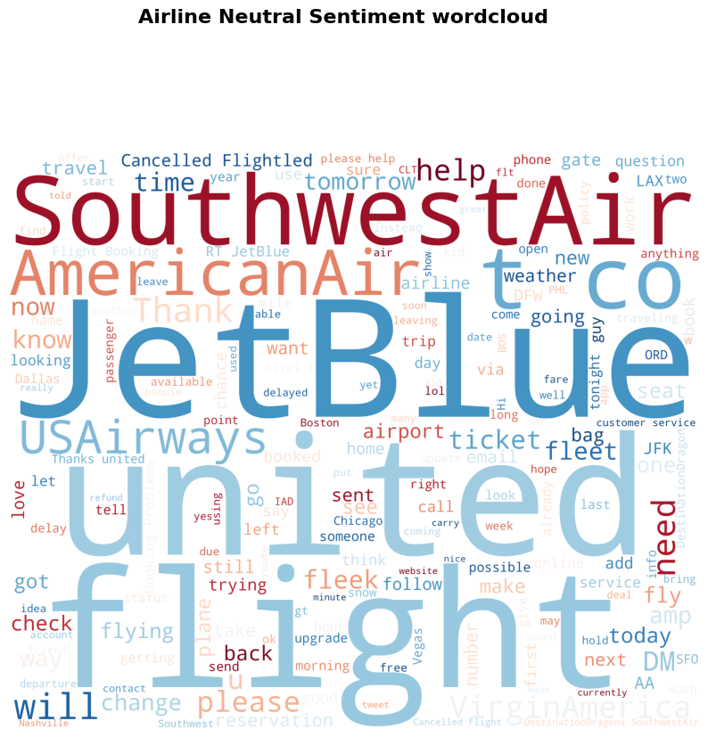

```python
plt.figure(1, figsize = (10, 10))
  plt.suptitle("Airline Neutral Sentiment wordcloud", fontsize=16, fontweight='bold')
  # Using the .imshow() method of matplotlib.pyplot to display the Word Cloud as an image.
  plt.imshow(wordcloud)
  plt.axis('off')
  plt.show()
```

**Other insights**

**Date related**

```python
dataw['tweet_created'] = pd.to_datetime(data["tweet_created"], format='%Y-%m-%d %H:%M:%S %z')
```

```python
# Extract year and month from 'tweet_created' column
  dataw['year'] = dataw['tweet_created'].dt.year
  dataw['month'] = dataw['tweet_created'].dt.month
```

```python
earliest_date = dataw['tweet_created'].min()
  latest_date = dataw['tweet_created'].max()

  print("Earliest date: ", earliest_date)
  print("Latest date: ",latest_date)
```

```
Earliest date:  2015-02-16 23:36:05-08:00
  Latest date:  2015-02-24 11:53:37-08:00
```

Notice that all dates are between 2015/02/16 and 2015/02/24.

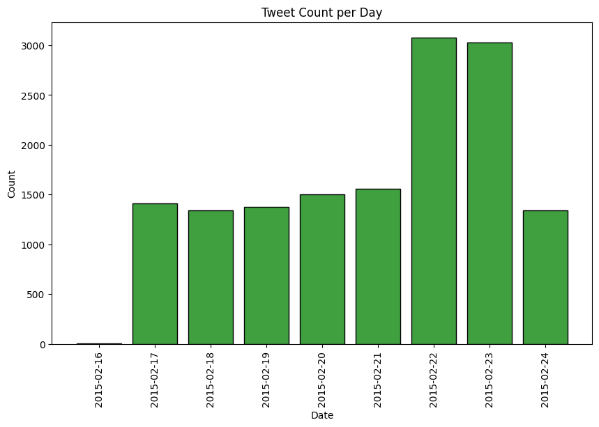

```python
#Extract day
  dataw['day'] = dataw['tweet_created'].dt.date

  #plot histogram
  fig, ax = plt.subplots(figsize=(10,6))
  sns.histplot(data=dataw, x='day', binwidth=1, color='green', shrink =.8)

  #set the labels and title
  ax.set_xlabel('Date')
  ax.set_ylabel('Count')
  ax.set_title('Tweet Count per Day')

  #rotate x-axis labels for better visibility
  plt.xticks(rotation=90)

  #show plot
  plt.show()
```

```python
# Group by 'day' and count the number of tweets
  tweet_counts = dataw.groupby('day').size().reset_index(name='count')

  # Print the table
  print(tweet_counts)
```

```
          day  count
  0  2015-02-16      4
  1  2015-02-17   1408
  2  2015-02-18   1344
  3  2015-02-19   1376
  4  2015-02-20   1500
  5  2015-02-21   1557
  6  2015-02-22   3079
  7  2015-02-23   3028
  8  2015-02-24   1344
```

The dataset only includes data from a very small range of dates. From 02/16/2015 to 02/24/2015, that is only nine days.

During this range of dates, severe winter conditions disrupted air travel in the United States. Numerous flight cancellations and delays at airports across the country occurred. Airlines had to adjust their schedules and make accommodations for the inclement weather. Passengers faced difficulties reaching their destinations on time, and some flights were grounded altogether.

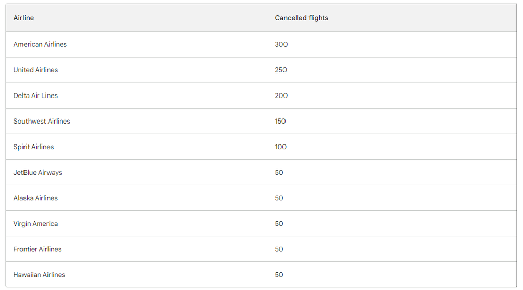

American Airlines has 300 flights cancelled, United Airlines 250, Delta Airlines 200, Southwest Airlines 150, Virgin America 50.

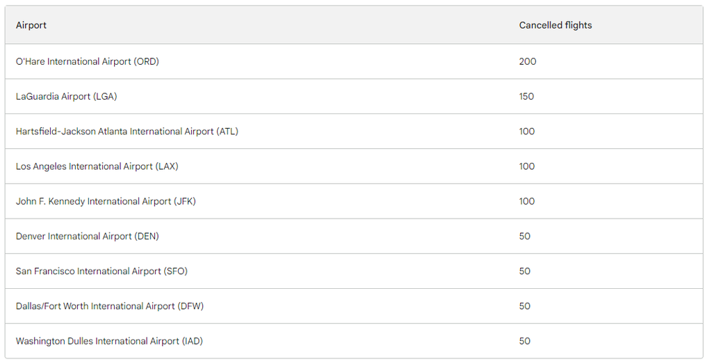

Chicago O'Hare had 200 cancelled flights, NYC La Guardia 150, Atlanta 100, LAX 100, NYC JFK 100.

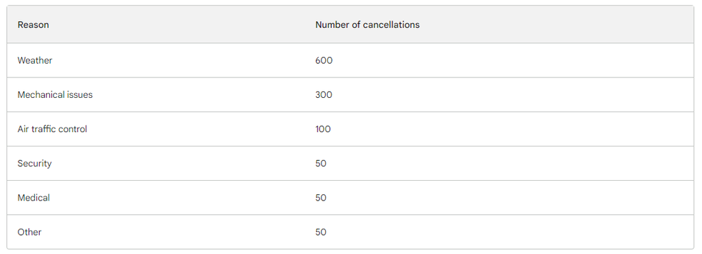

The overwhelming reason for cancellations was weather.

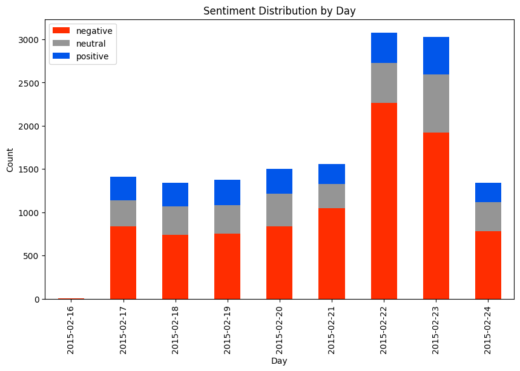

```python
# Group the data by 'day' and 'airline_sentiment'
  grouped_day_data = dataw.groupby(['day', 'airline_sentiment']).size().unstack()

  # Calculate the percentages for each category within each day
  grouped_day_data_percentages = grouped_day_data.div(grouped_day_data.sum(axis=1), axis=0) * 100

  # Create a stacked bar plot
  fig, ax = plt.subplots(figsize=(10, 6))
  grouped_day_data.plot(kind='bar', stacked=True, ax=ax, color=color_dict)

  # Annotate the percentages on the plot
  for day in grouped_day_data.index:
      total = grouped_day_data.loc[day].sum()
      for category in grouped_day_data.columns:
          count = grouped_day_data.loc[day, category]
          percentage = grouped_day_data_percentages.loc[day, category]
          if count > 0 and not pd.isna(percentage):  # Check if count and percentage are valid
              ax.annotate(f'{percentage:.1f}%', (day, count), ha='center', va='bottom')


  # Set the labels and title
  ax.set_xlabel('Day')
  ax.set_ylabel('Count')
  ax.set_title('Sentiment Distribution by Day')
  ax.legend()

  # Show the plot
  plt.show()
```

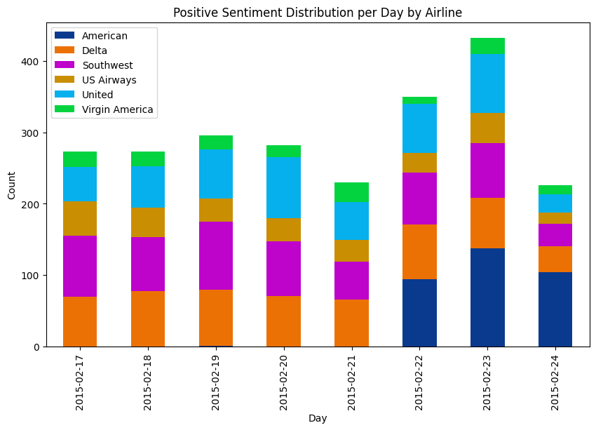

```python
#positive sentiment
  positive_sent = dataw[dataw['airline_sentiment']=='positive']

  # Group the data by 'day' and 'airline_sentiment'
  grouped_day_airline_pos = positive_sent.groupby(['day', 'airline']).size().unstack()

  # Calculate the percentages for each category within each day
  grouped_day_airline_pos_percentages = grouped_day_data.div(grouped_day_airline_pos.sum(axis=1), axis=0) * 100

  # Create a stacked bar plot
  fig, ax = plt.subplots(figsize=(10, 6))
  grouped_day_airline_pos.plot(kind='bar', stacked=True, ax=ax, color=color_dict)

  # Set the labels and title
  ax.set_xlabel('Day')
  ax.set_ylabel('Count')
  ax.set_title('Positive Sentiment Distribution per Day by Airline')
  ax.legend()

  # Show the plot
  plt.show()
```

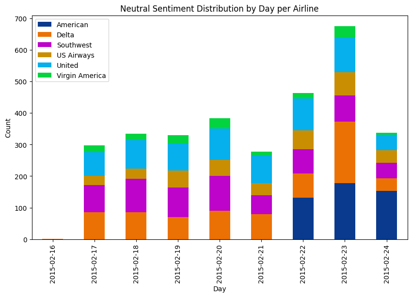

```python
#neutral sentiment
  neutral_sent = dataw[dataw['airline_sentiment']=='neutral']

  # Group the data by 'day' and 'airline_sentiment'
  grouped_day_airline_neu = neutral_sent.groupby(['day', 'airline']).size().unstack()

  # Calculate the percentages for each category within each day
  grouped_day_airline_neu_percentages = grouped_day_data.div(grouped_day_airline_neu.sum(axis=1), axis=0) * 100

  # Create a stacked bar plot
  fig, ax = plt.subplots(figsize=(10, 6))
  grouped_day_airline_neu.plot(kind='bar', stacked=True, ax=ax, color=color_dict)

  # Set the labels and title
  ax.set_xlabel('Day')
  ax.set_ylabel('Count')
  ax.set_title('Neutral Sentiment Distribution by Day per Airline')
  ax.legend()

  # Show the plot
  plt.show()
```

**Negative Reasons**

```python
neg_reasons = dataw['negativereason'].unique()
  null_neg_reasons = dataw['negativereason'].isna().sum()
  neg_reasons_ct = dataw['negativereason'].value_counts()
  neg_reasons_ct
```

```
Customer Service Issue         2910
  Late Flight                    1665
  Can't Tell                     1190
  Cancelled Flight                847
  Lost Luggage                    724
  Bad Flight                      580
  Flight Booking Problems         529
  Flight Attendant Complaints     481
  longlines                       178
  Damaged Luggage                  74
  Name: negativereason, dtype: int64
```

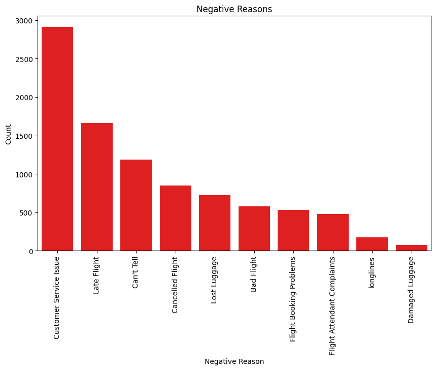

```python
#plot negative reasons
  # Sort the data by count in descending order
  sorted_data = dataw['negativereason'].value_counts().sort_values(ascending=False)

  # Plot negative reasons
  fig, ax = plt.subplots(figsize=(10, 6))
  sns.barplot(x=sorted_data.index, y=sorted_data.values, color='red')

  # Set the labels and title
  ax.set_xlabel('Negative Reason')
  ax.set_ylabel('Count')
  ax.set_title('Negative Reasons')

  # Rotate x-axis labels for better visibility
  plt.xticks(rotation=90)

  plt.show()
```

Customer service issues are the number one reason for negative sentiments. Late flights, cancelled flights, lost luggage are other reasons.

### **Understand of Data Columns**

**Dropping unnecessary columns**

Drop the following columns:

- tweet_id: unique id number of the tweet.
- airline_sentiment_confidence: how confident the airline sentiment is.
- negativereason: Very short reference to why the sentiment was negative.
- airline_sentiment_gold: I am not sure what this is.
- name: Name of the tweeter
- negativereason_gold: I am not sure what this is.
- retweet_count: How many times the tweet was retweeted.
- tweet_coord: geographical coordinates where the tweet originated in latitude and longitude.
- tweet_created: data and time when the tweet was created.
- tweet_location: the location where the tweeter originated the tweet.
- user_timezone: timezone where the user lives.

```python
#drop unnecessary columns
  data_wdf = dataw.drop(['tweet_id','negativereason_confidence','airline_sentiment_confidence','negativereason','airline_sentiment_gold','name','negativereason_gold','retweet_count','retweet_count',
                         'tweet_coord','tweet_created','tweet_location','user_timezone', 'year','month','day'], axis=1)
```

**Dropping duplicated entries**

```python
#drop duplicates, keeping last
  data_nodup = data_wdf.drop_duplicates(keep='last')
```

```python
#check duplicates
  data_nodup.duplicated().sum()
```

```
0
```

No duplicates.

**Rechecking data shape**

```python
#display shape after dropping duplicates, null values, and unnecessary columns.
  data_nodup.shape
```

```
(14452, 3)
```

14,452 rows and 3 columns.

**Null Values**

```python
data_nodup.info()
```

```
<class 'pandas.core.frame.DataFrame'>
  Int64Index: 14452 entries, 0 to 14639
  Data columns (total 3 columns):
   #   Column             Non-Null Count  Dtype
  ---  ------             --------------  -----
   0   airline_sentiment  14452 non-null  object
   1   airline            14452 non-null  object
   2   text               14452 non-null  object
  dtypes: object(3)
  memory usage: 451.6+ KB
```

There are no null values.

```python
#show head
  data_nodup.head(10)
```

|  | airline_sentiment | airline | text |
| --- | --- | --- | --- |
| 0 | neutral | Virgin America | @VirginAmerica What @dhepburn said. |
| 1 | positive | Virgin America | @VirginAmerica plus you've added commercials to the experience... tacky. |
| 2 | neutral | Virgin America | @VirginAmerica I didn't today... Must mean I need to take another trip! |
| 3 | negative | Virgin America | @VirginAmerica it's really aggressive to blast obnoxious "entertainment" in your guests' faces &amp; they have little recourse |
| 4 | negative | Virgin America | @VirginAmerica and it's a really big bad thing about it |
| 5 | negative | Virgin America | @VirginAmerica seriously would pay $30 a flight for seats that didn't have this playing.\nit's really the only bad thing about flying VA |
| 6 | positive | Virgin America | @VirginAmerica yes, nearly every time I fly VX this “ear worm” won’t go away :) |
| 7 | neutral | Virgin America | @VirginAmerica Really missed a prime opportunity for Men Without Hats parody, there. https://t.co/mWpG7grEZP |
| 8 | positive | Virgin America | @virginamerica Well, I didn't…but NOW I DO! :-D |
| 9 | positive | Virgin America | @VirginAmerica it was amazing, and arrived an hour early. You're too good to me. |

### **Data Pre-Processing**

Data Pre - Processing

- Pre-process the text data for classification a. Html tag removal. b. Tokenization. c. Remove the numbers. d. Removal of Special Characters and Punctuations. e. Removal of stopwords f. Conversion to lowercase. g. Lemmatize or stemming. h. Join the words in the list to convert them back to text string in the data frame. - Print the first 5 rows of data after pre-processing.

### **Data Pre-Processing**

1- Remove html tags

2- Expand contractions

3- tokenization

4- remove numbers

5- remove special characters and punctuations

6- remove stopwords

7- conversion to lowercase

8- lemmatize or stemming

9- join words in the list to convert them back to text string in the dataframe

**Remove html tags**

[figure not shown]